# Data Analysis & Visualization Report

After the data is cleaned and ready to be analyzed and visualized, I thought of what useful information I can get from the data so I found 3 insights and 3 visualizations.

1. The relation between retweet_count and favorite_count

In weratedogs page on twitter, each tweet has retweet count and favorite count, retweet is like share in facebook and favorite count is the number of likes on the tweet and they refer to the interaction on the tweet over time, so I wanted to know the relation between them to see if they increase together or not and what is the correlation coefficient between them.

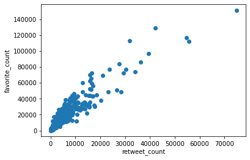

From the scatter plot I concluded that the relation between them is very strong in the positive direction which means that when retweet_count increases over time, favorite_count also increases and using `corr` method, the correlation coefficient is 0.93

1. The distribution of the ratings between the dogs

People in weratedogs page rates dogs depending on the shape of the dog, its color and its face, also each one like some dog breeds, so I wanted to know the distribution of the ratings of the dogs to know the average of the ratings, the maximum of them and the minimum.

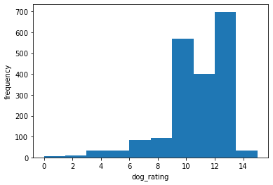

From this histogram plot, it is left skewed which means that the median of rating is bigger than the mean which equals 10.53, also the max rating is 14 which is not an issue because dog lovers like to give the dogs ratings that are higher than the full rating which is 10 and this means that they like those dogs very much. The mean means that in average dogs are given rating higher than 10 by a little difference.

1. The most frequency stage from dog_stages

People who rates dogs classifies them to 4 stages: doggo, puppo, pupper and floofer, some of the dogs are classified with more than 1 stage like doggo-pupper and so on. I wanted to know what is the most popular stage from them.

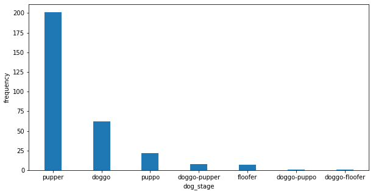

From this bar plot, I concluded that pupper stage is the most popular stage with about 200 dogs that are classified with and the double stages like doggo-pupper have low frequency.